# **Preprocessing**

Load the dataset

```python
import numpy as np
from medmnist import OCTMNIST, INFO
from torch.utils.data import DataLoader

# Load raw
raw_train = OCTMNIST(split='train', download=True)
raw_val = OCTMNIST(split='val', download=True)
raw_test = OCTMNIST(split='test', download=True)

# Combine all data for stats
all_images = np.concatenate([raw_train.imgs, raw_val.imgs, raw_test.imgs], axis=0)

# Check shape
print(f"Raw image shape: {all_images.shape}")
```

```
Raw image shape: (109309, 28, 28)
```

```python
# Basic pixel stats
min_pixel = all_images.min()
max_pixel = all_images.max()
mean_pixel = all_images.mean()
std_pixel = all_images.std()

print(f"Min Pixel Value     : {min_pixel}")
print(f"Max Pixel Value     : {max_pixel}")
print(f"Mean Pixel Value    : {mean_pixel:.4f}")
print(f"Std Dev of Pixels   : {std_pixel:.4f}")
```

```
Min Pixel Value     : 0
Max Pixel Value     : 255
Mean Pixel Value    : 48.2002
Std Dev of Pixels   : 50.0744
```

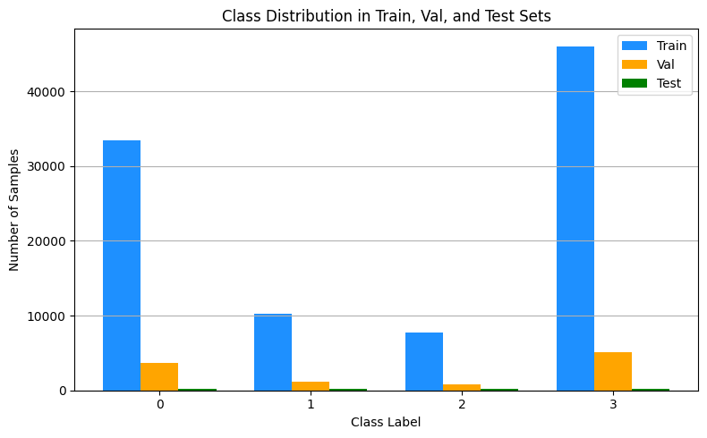

```python
import matplotlib.pyplot as plt
import numpy as np

# Step 1: Get labels
train_labels = raw_train.labels.flatten()
val_labels   = raw_val.labels.flatten()
test_labels  = raw_test.labels.flatten()

# Step 2: Count per class
train_counts = np.bincount(train_labels, minlength=4)
val_counts   = np.bincount(val_labels, minlength=4)
test_counts  = np.bincount(test_labels, minlength=4)

# Step 3: Plot
width = 0.25
classes = np.arange(4)

plt.figure(figsize=(8,5))
plt.bar(classes - width, train_counts, width=width, label='Train', color='dodgerblue')
plt.bar(classes,         val_counts,   width=width, label='Val', color='orange')
plt.bar(classes + width, test_counts,  width=width, label='Test', color='green')

plt.xticks(classes)
plt.xlabel("Class Label")
plt.ylabel("Number of Samples")
plt.title("Class Distribution in Train, Val, and Test Sets")
plt.legend()
plt.grid(axis='y')
plt.tight_layout()
plt.show()
```

The bar chart above compares the class distributions across the train, validation, and test splits of the OCTMNIST dataset. While the overall dataset is well-structured, some class imbalance is evident in the training set, which may affect model performance. Handling this imbalance during training is necessary.

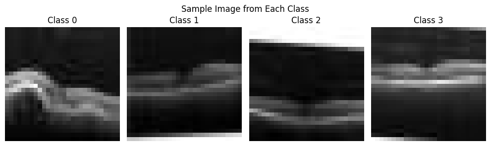

```python
import matplotlib.pyplot as plt

# Show one sample from each class (using raw_train)
fig, axs = plt.subplots(1, 4, figsize=(10, 3))
fig.suptitle("Sample Image from Each Class")

for cls in range(4):
    idx = np.where(raw_train.labels.flatten() == cls)[0][0]
    axs[cls].imshow(raw_train.imgs[idx], cmap='gray')
    axs[cls].axis('off')
    axs[cls].set_title(f"Class {cls}")

plt.tight_layout()
plt.show()
```

This figure displays one OCT image from each of the four classes, providing a quick overview of the visual differences in retinal disease patterns captured by the dataset.

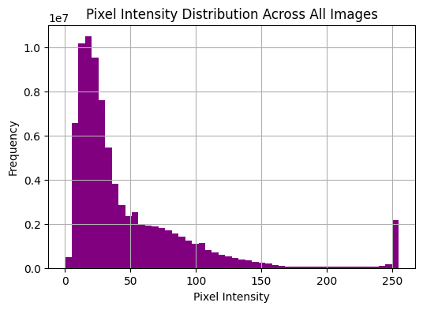

```python
plt.figure(figsize=(6,4))
plt.hist(all_images.flatten(), bins=50, color='purple')
plt.xlabel("Pixel Intensity")
plt.ylabel("Frequency")
plt.title("Pixel Intensity Distribution Across All Images")
plt.grid(True)
plt.show()
```

This histogram shows how pixel intensities are distributed across all images in the dataset. Most pixel values are clustered in a narrow range, confirming the need to normalize them before model training.

Converts [0,255] to [0.0,1.0]

```python
import torchvision.transforms as transforms

transform = transforms.Compose([
    transforms.ToTensor(),
    transforms.Normalize((0.4747,), (0.2871,))
])
```

Reload Dataset with Transformation

```python
train_dataset = OCTMNIST(split='train', transform=transform, download=True)
val_dataset   = OCTMNIST(split='val', transform=transform, download=True)
test_dataset  = OCTMNIST(split='test', transform=transform, download=True)
```

Create DataLoaders

```python
from torch.utils.data import DataLoader

batch_size = 64

train_loader = DataLoader(train_dataset, batch_size=batch_size, shuffle=True)
val_loader   = DataLoader(val_dataset, batch_size=batch_size, shuffle=False)
test_loader  = DataLoader(test_dataset, batch_size=batch_size, shuffle=False)
```

```python
images, labels = next(iter(train_loader))
labels = labels.squeeze()
print(f"Image batch shape: {images.shape}")
print(f"Label batch shape: {labels.shape}")
```

```
Image batch shape: torch.Size([64, 1, 28, 28])
Label batch shape: torch.Size([64])
```

Trying to handle class imbalance

```python
import numpy as np
from sklearn.utils.class_weight import compute_class_weight

# Flatten the labels
train_labels = raw_train.labels.flatten()

# Compute class weights with sklearn
class_weights = compute_class_weight(
    class_weight='balanced',
    classes=np.unique(train_labels),
    y=train_labels
)

# Convert to torch tensor
import torch
class_weights_tensor = torch.tensor(class_weights, dtype=torch.float32)
print("Class weights:", class_weights_tensor)
```

```
Class weights: tensor([0.7278, 2.3861, 3.1428, 0.5295])
```

```python
import torch.nn as nn

loss_fn = nn.CrossEntropyLoss(weight=class_weights_tensor)
```

# Defining the Neural Network

# **CNN**

```python
import torch.nn as nn
import torch.nn.functional as F

class OCTModel(nn.Module):
    def __init__(self):
        super(OCTModel, self).__init__()
        self.conv1 = nn.Conv2d(1, 32, kernel_size=3, padding=1)
        self.pool = nn.MaxPool2d(2, 2)
        self.conv2 = nn.Conv2d(32, 64, kernel_size=3, padding=1)
        self.fc1 = nn.Linear(64 * 7 * 7, 128)
        self.dropout = nn.Dropout(0.25)
        self.fc2 = nn.Linear(128, 4)

    def forward(self, x):
        x = self.pool(F.relu(self.conv1(x)))
        x = self.pool(F.relu(self.conv2(x)))
        x = x.view(-1, 64 * 7 * 7)  # Flatten
        x = F.relu(self.fc1(x))
        x = self.dropout(x)
        x = self.fc2(x)
        return x
```

**Output** Activation Function

I didn’t manually apply an activation function like `Softmax` at the output layer, I used `nn.CrossEntropyLoss`, which already includes `LogSoftmax` internally. This is avoids applying softmax twice. So, the output activation is effectively handled through the loss function.

Model summary

```python
!pip install -q torchinfo
from torchinfo import summary

model = OCTModel()
summary(model, input_size=(64, 1, 28, 28))
```

```
==========================================================================================
Layer (type:depth-idx)                   Output Shape              Param #
==========================================================================================
OCTModel                                 [64, 4]                   --
├─Conv2d: 1-1                            [64, 32, 28, 28]          320
├─MaxPool2d: 1-2                         [64, 32, 14, 14]          --
├─Conv2d: 1-3                            [64, 64, 14, 14]          18,496
├─MaxPool2d: 1-4                         [64, 64, 7, 7]            --
├─Linear: 1-5                            [64, 128]                 401,536
├─Dropout: 1-6                           [64, 128]                 --
├─Linear: 1-7                            [64, 4]                   516
==========================================================================================
Total params: 420,868
Trainable params: 420,868
Non-trainable params: 0
Total mult-adds (Units.MEGABYTES): 273.80
==========================================================================================
Input size (MB): 0.20
Forward/backward pass size (MB): 19.34
Params size (MB): 1.68
Estimated Total Size (MB): 21.22
==========================================================================================
```

# **Training the Neural Network**

Define Optimizer, Epochs, and Timer

```python
import time
import torch.nn as nn
import torch.optim as optim

model = OCTModel()
optimizer = optim.Adam(model.parameters(), lr=0.001)
num_epochs = 25
```

Learning Rate **Scheduler**

```python
from torch.optim.lr_scheduler import ReduceLROnPlateau
scheduler = ReduceLROnPlateau(optimizer, mode='min', factor=0.5, patience=3)
```

Training & Validation Loop

```python
train_losses = []
val_losses = []
train_accuracies = []
val_accuracies = []

best_val_acc = 0.0
start_time = time.time()

for epoch in range(num_epochs):
    model.train()
    running_loss = 0.0
    correct = 0
    total = 0

    for images, labels in train_loader:
        labels = labels.squeeze()
        outputs = model(images)
        loss = loss_fn(outputs, labels)

        optimizer.zero_grad()
        loss.backward()
        optimizer.step()

        running_loss += loss.item()
        _, predicted = torch.max(outputs.data, 1)
        total += labels.size(0)
        correct += (predicted == labels).sum().item()

    train_loss = running_loss / len(train_loader)
    train_acc = correct / total
    train_losses.append(train_loss)
    train_accuracies.append(train_acc)

    # Validation loop
    model.eval()
    val_loss = 0.0
    correct = 0
    total = 0
    with torch.no_grad():
        for val_images, val_labels in val_loader:
            val_labels = val_labels.squeeze()
            val_outputs = model(val_images)
            loss = loss_fn(val_outputs, val_labels)

            val_loss += loss.item()
            _, predicted = torch.max(val_outputs.data, 1)
            total += val_labels.size(0)
            correct += (predicted == val_labels).sum().item()

    val_loss /= len(val_loader)
    val_acc = correct / total
    val_losses.append(val_loss)
    val_accuracies.append(val_acc)
    scheduler.step(val_loss)

    print(f"Epoch [{epoch+1}/{num_epochs}] | "
          f"Train Loss: {train_loss:.4f} | Val Loss: {val_loss:.4f} | "
          f"Train Acc: {train_acc:.4f} | Val Acc: {val_acc:.4f}")

    # Save best model
    if val_acc > best_val_acc:
        best_val_acc = val_acc
        torch.save(model.state_dict(), "a0_part_3_dropout_lrs_model.pt")
```

```
Epoch [1/25] | Train Loss: 0.8497 | Val Loss: 0.6672 | Train Acc: 0.7043 | Val Acc: 0.7246
Epoch [2/25] | Train Loss: 0.6397 | Val Loss: 0.5768 | Train Acc: 0.7672 | Val Acc: 0.7365
Epoch [3/25] | Train Loss: 0.5756 | Val Loss: 0.5303 | Train Acc: 0.7894 | Val Acc: 0.8223
Epoch [4/25] | Train Loss: 0.5389 | Val Loss: 0.5351 | Train Acc: 0.8040 | Val Acc: 0.8211
Epoch [5/25] | Train Loss: 0.5085 | Val Loss: 0.4973 | Train Acc: 0.8154 | Val Acc: 0.8289
Epoch [6/25] | Train Loss: 0.4834 | Val Loss: 0.4872 | Train Acc: 0.8243 | Val Acc: 0.8254
Epoch [7/25] | Train Loss: 0.4630 | Val Loss: 0.4750 | Train Acc: 0.8320 | Val Acc: 0.8323
Epoch [8/25] | Train Loss: 0.4402 | Val Loss: 0.4720 | Train Acc: 0.8404 | Val Acc: 0.8517
Epoch [9/25] | Train Loss: 0.4227 | Val Loss: 0.4752 | Train Acc: 0.8456 | Val Acc: 0.8071
Epoch [10/25] | Train Loss: 0.4118 | Val Loss: 0.4583 | Train Acc: 0.8513 | Val Acc: 0.8177
Epoch [11/25] | Train Loss: 0.3938 | Val Loss: 0.4660 | Train Acc: 0.8559 | Val Acc: 0.8733
Epoch [12/25] | Train Loss: 0.3760 | Val Loss: 0.4419 | Train Acc: 0.8636 | Val Acc: 0.8519
Epoch [13/25] | Train Loss: 0.3726 | Val Loss: 0.4490 | Train Acc: 0.8638 | Val Acc: 0.8697
Epoch [14/25] | Train Loss: 0.3574 | Val Loss: 0.4505 | Train Acc: 0.8689 | Val Acc: 0.8581
Epoch [15/25] | Train Loss: 0.3468 | Val Loss: 0.4468 | Train Acc: 0.8719 | Val Acc: 0.8724
Epoch [16/25] | Train Loss: 0.3374 | Val Loss: 0.4496 | Train Acc: 0.8748 | Val Acc: 0.8792
Epoch [17/25] | Train Loss: 0.3037 | Val Loss: 0.4372 | Train Acc: 0.8869 | Val Acc: 0.8661
Epoch [18/25] | Train Loss: 0.2936 | Val Loss: 0.4300 | Train Acc: 0.8912 | Val Acc: 0.8633
Epoch [19/25] | Train Loss: 0.2855 | Val Loss: 0.4602 | Train Acc: 0.8927 | Val Acc: 0.8769
Epoch [20/25] | Train Loss: 0.2807 | Val Loss: 0.4547 | Train Acc: 0.8944 | Val Acc: 0.8792
Epoch [21/25] | Train Loss: 0.2751 | Val Loss: 0.4614 | Train Acc: 0.8967 | Val Acc: 0.8749
Epoch [22/25] | Train Loss: 0.2707 | Val Loss: 0.4504 | Train Acc: 0.8972 | Val Acc: 0.8657
Epoch [23/25] | Train Loss: 0.2478 | Val Loss: 0.4547 | Train Acc: 0.9054 | Val Acc: 0.8766
Epoch [24/25] | Train Loss: 0.2442 | Val Loss: 0.4563 | Train Acc: 0.9079 | Val Acc: 0.8796
Epoch [25/25] | Train Loss: 0.2400 | Val Loss: 0.4600 | Train Acc: 0.9084 | Val Acc: 0.8840
```

```python
end_time = time.time()
print(f"\nTraining completed in {(end_time - start_time):.2f} seconds")
```

```
Training completed in 3580.28 seconds
```

Load Best Model & Evaluate on Test Set

```python
model.load_state_dict(torch.load("a0_part_3_dropout_lrs_model.pt"))
model.eval()

from sklearn.metrics import accuracy_score, precision_recall_fscore_support

y_true = []
y_pred = []

with torch.no_grad():
    for images, labels in test_loader:
        labels = labels.squeeze()
        outputs = model(images)
        _, predicted = torch.max(outputs.data, 1)
        y_true.extend(labels.numpy())
        y_pred.extend(predicted.numpy())

# Calculate metrics
accuracy = accuracy_score(y_true, y_pred)
precision, recall, f1, _ = precision_recall_fscore_support(y_true, y_pred, average='weighted')

print(f"Test Accuracy : {accuracy:.4f}")
print(f"Precision     : {precision:.4f}")
print(f"Recall        : {recall:.4f}")
print(f"F1 Score      : {f1:.4f}")
```

```
Test Accuracy : 0.7610
Precision     : 0.7880
Recall        : 0.7610
F1 Score      : 0.7528
```

Plot Loss and Accuracy Curves

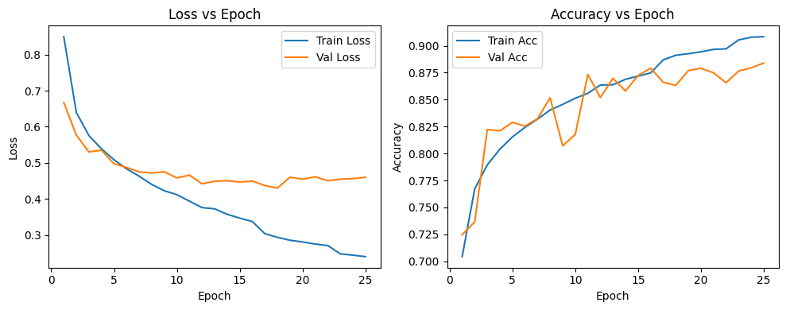

```python
import matplotlib.pyplot as plt

epochs = range(1, num_epochs + 1)

plt.figure(figsize=(10, 4))

# Loss Plot
plt.subplot(1, 2, 1)
plt.plot(epochs, train_losses, label='Train Loss')
plt.plot(epochs, val_losses, label='Val Loss')
plt.xlabel('Epoch')
plt.ylabel('Loss')
plt.title('Loss vs Epoch')
plt.legend()

# Accuracy Plot
plt.subplot(1, 2, 2)
plt.plot(epochs, train_accuracies, label='Train Acc')
plt.plot(epochs, val_accuracies, label='Val Acc')
plt.xlabel('Epoch')
plt.ylabel('Accuracy')
plt.title('Accuracy vs Epoch')
plt.legend()

plt.tight_layout()
plt.show()
```

Confusion Matrix

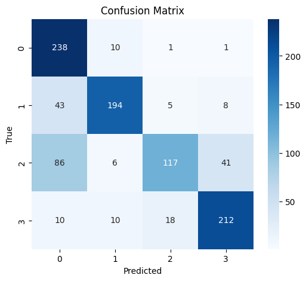

```python
from sklearn.metrics import confusion_matrix
import seaborn as sns
import numpy as np

conf_mat = confusion_matrix(y_true, y_pred)

plt.figure(figsize=(6,5))
sns.heatmap(conf_mat, annot=True, fmt='d', cmap='Blues')
plt.xlabel("Predicted")
plt.ylabel("True")
plt.title("Confusion Matrix")
plt.show()
```

ROC Curve (One-vs-Rest)

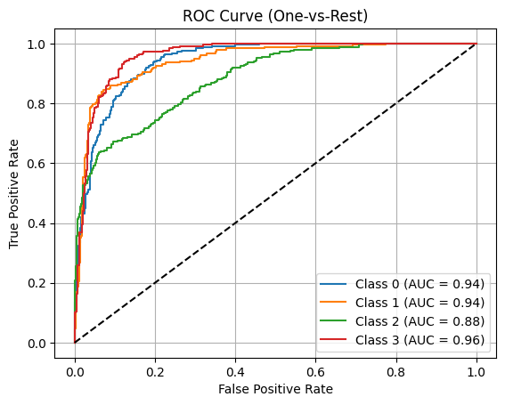

```python
from sklearn.preprocessing import label_binarize
from sklearn.metrics import roc_curve, auc
from sklearn.metrics import RocCurveDisplay

import numpy as np

# Re-run test to get raw output logits
y_true_roc = []
y_score_roc = []

with torch.no_grad():
    for images, labels in test_loader:
        labels = labels.squeeze()
        outputs = model(images)
        y_true_roc.extend(labels.numpy())
        y_score_roc.extend(outputs.numpy())

y_true_roc = np.array(y_true_roc)
y_score_roc = np.array(y_score_roc)

# Binarize the labels for one-vs-rest ROC
y_true_bin = label_binarize(y_true_roc, classes=[0,1,2,3])

# Plot ROC for each class
for i in range(4):
    fpr, tpr, _ = roc_curve(y_true_bin[:, i], y_score_roc[:, i])
    roc_auc = auc(fpr, tpr)
    plt.plot(fpr, tpr, label=f"Class {i} (AUC = {roc_auc:.2f})")

plt.plot([0, 1], [0, 1], 'k--')
plt.title("ROC Curve (One-vs-Rest)")
plt.xlabel("False Positive Rate")
plt.ylabel("True Positive Rate")
plt.legend(loc="lower right")
plt.grid(True)
plt.show()
```

Saving Model data for comparison

```python
import pickle

with open("a0_part_3_dropout_lrs_model.pkl", "wb") as f:
    pickle.dump({
        'train_losses': train_losses,
        'val_losses': val_losses,
        'train_accuracies': train_accuracies,
        'val_accuracies': val_accuracies,
        'training_time': end_time - start_time,
        'test_metrics': {
            'accuracy': accuracy,
            'precision': precision,
            'recall': recall,
            'f1': f1
        }
    }, f)
```

# **Comparison**

[output not shown]

Distributions

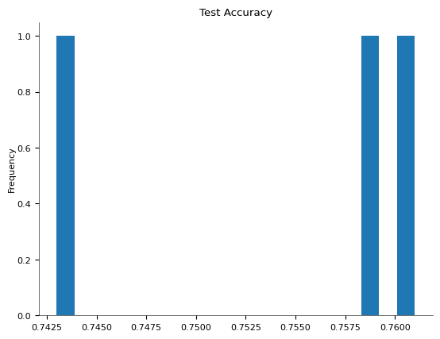

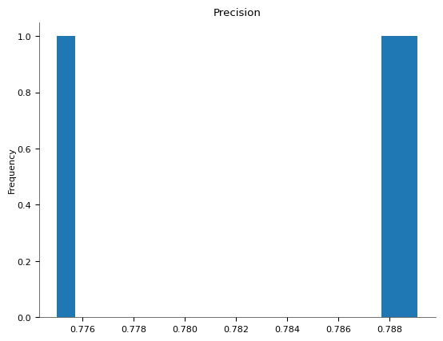

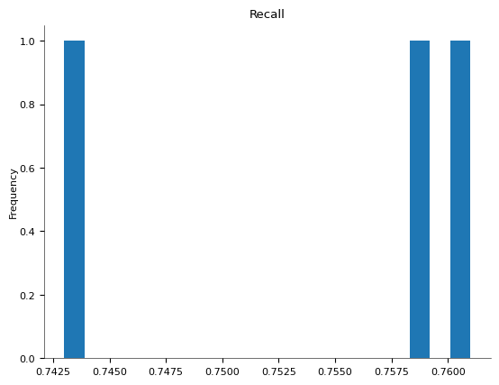

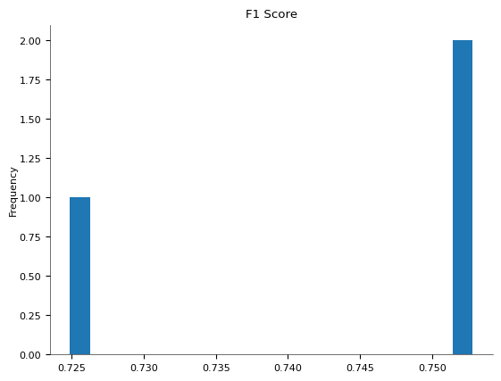

Categorical distributions

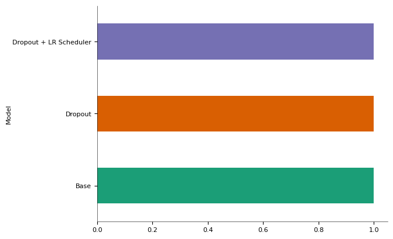

2-d distributions

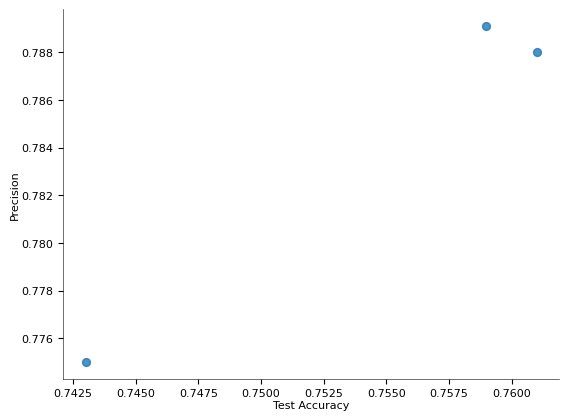

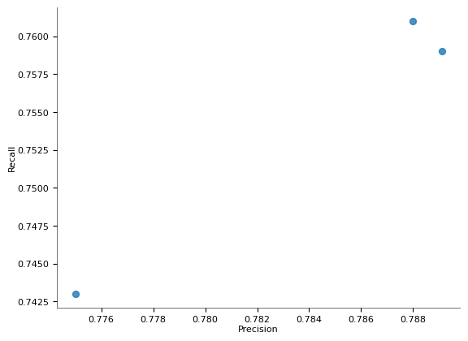

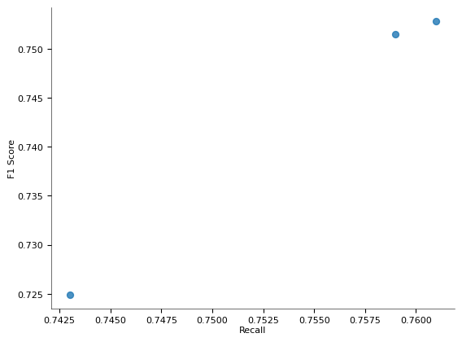

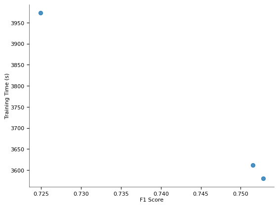

Time series

[figure not shown]

[figure not shown]

[figure not shown]

[30 more figures not shown]

```python
import pickle
import pandas as pd

def load_results(filename):
    with open(filename, "rb") as f:
        return pickle.load(f)

# Load all .pkl result files
base_results = load_results("a0_part_3_base_model.pkl")
dropout_results = load_results("a0_part_3_dropout_model.pkl")
dropout_lrs_results = load_results("a0_part_3_dropout_lrs_model.pkl")

# Build comparison table
summary = {
    "Model": ["Base", "Dropout", "Dropout + LR Scheduler"],
    "Test Accuracy": [
        round(base_results["test_metrics"]["accuracy"], 4),
        round(dropout_results["test_metrics"]["accuracy"], 4),
        round(dropout_lrs_results["test_metrics"]["accuracy"], 4),
    ],
    "Precision": [
        round(base_results["test_metrics"]["precision"], 4),
        round(dropout_results["test_metrics"]["precision"], 4),
        round(dropout_lrs_results["test_metrics"]["precision"], 4),
    ],
    "Recall": [
        round(base_results["test_metrics"]["recall"], 4),
        round(dropout_results["test_metrics"]["recall"], 4),
        round(dropout_lrs_results["test_metrics"]["recall"], 4),
    ],
    "F1 Score": [
        round(base_results["test_metrics"]["f1"], 4),
        round(dropout_results["test_metrics"]["f1"], 4),
        round(dropout_lrs_results["test_metrics"]["f1"], 4),
    ],
    "Training Time (s)": [
        round(base_results["training_time"], 2),
        round(dropout_results["training_time"], 2),
        round(dropout_lrs_results["training_time"], 2),
    ]
}

# Display as a DataFrame
df = pd.DataFrame(summary)
df
```

```python
import pickle

# Load the saved metrics
with open("a0_part_3_dropout_lrs_model.pkl", "rb") as f:
    results = pickle.load(f)

# Extract values
train_loss = results['train_losses'][-1]
val_loss = results['val_losses'][-1]
train_acc = results['train_accuracies'][-1]
val_acc = results['val_accuracies'][-1]
training_time = results['training_time']

test_metrics = results['test_metrics']
test_acc = test_metrics['accuracy']
precision = test_metrics['precision']
recall = test_metrics['recall']
f1 = test_metrics['f1']

# Print everything
print("Training Accuracy:", train_acc)
print("Training Loss:", train_loss)
print("Validation Accuracy:", val_acc)
print("Validation Loss:", val_loss)
print("Test Accuracy:", test_acc)
print("Test Precision:", precision)
print("Test Recall:", recall)
print("Test F1 Score:", f1)
print("Training Time (s):", training_time)
```

```
Training Accuracy: 0.9084296808477897
Training Loss: 0.23999069248670785
Validation Accuracy: 0.8839549483013294
Validation Loss: 0.45995094609611176
Test Accuracy: 0.761
Test Precision: 0.7880163639880643
Test Recall: 0.761
Test F1 Score: 0.7528232604867232
Training Time (s): 3580.275575876236
```